# ECO 5585 : Prérequis et MPC

Andy Sabrina Guerrier (8851496)

2025-08-25

# Résumé

Ce document présente un survol ciblé de mon parcours en Mathématiques financières et économie, en soulignant les cours fondamentaux et avancés pertinents pour **ECO 5585 – Économétrie I**.

Ce complément au relevé de notes compare la MPC globale à la MPC récente, mettant en évidence la progression après mon premier contact avec l’économétrie financière.

*Note : le jeu de données utilisé pour les calculs a été construit manuellement à partir de mon relevé de notes complet. Le code et le jeu de données peuvent être consultés sur GitHub.*

## Cours pertinents et comparaison de la MPC

Cours fondamentaux et avancés pertinents pour ECO 5585

| Trimestre | Cours | Description | Note |
| --- | --- | --- | --- |
| Automne 2020 | MAT 2742 | Introduction à l’algèbre linéaire appliquée | A- |
| Hiver 2022 | MAT 3775 | Analyse de la régression | B |
| Hiver 2023 | ECO 4585 | Économétrie financière | C+ |
| Hiver 2024 | MAT 3379 | Introduction to Time Series Analysis | A- |
| Hiver 2024 | MAT 3575 | Introduction à la statistique mathématique | A+ |
| Hiver 2025 | MAT 2125 | Elementary Real Analysis | B+ |

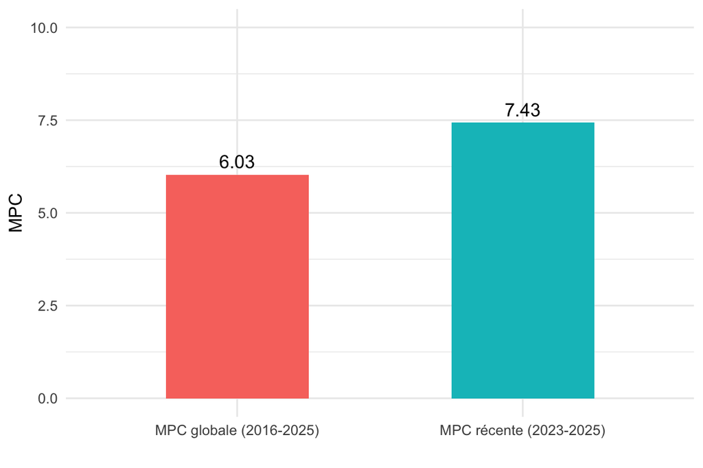

Comparaison des moyennes pondérées cumulées (MPC) globale et récente

## Synthèse de la progression académique

La MPC globale (2016‑2025) est de 6.03 (B), reflétant l’ensemble de mon parcours en Mathématiques financières et économie, avec 3 crédits restants pour l’obtention du diplôme.

La MPC récente (2023‑2025) s’élève à 7.43 (B+).

Cette trajectoire résulte d’une consolidation marquée de mes compétences quantitatives, particulièrement à travers les cours de mathématiques et statistiques avancées. Ma performance soutenue dans les derniers trimestres témoigne de la rigueur et de la préparation nécessaires pour aborder un cours d’économétrie de deuxième cycle.